# **From Valence to Virality: The Science Behind Streaming Hits** - A Spotify analysis

### **Introduction to coding and data management part 2 - Alessia Rustignoli**

### **Introduction**

This project explores the dynamics of music streaming by analyzing Spotify data to uncover what makes songs successful in the digital age. By examining audio features, genre trends, artist performance, and listener behavior, we reveal how streaming platforms shape, and are shaped by modern music consumption. The analysis focuses on three key questions: What sonic characteristics dominate streaming? How do genres and artists compete for attention? And how do seasonal and algorithmic factors influence what we listen to?

The data reveals clear patterns: pop and rap lead in streams, driven by high energy, danceability, and short runtimes optimized for playlists. Latin music and R&B emerge as strong seasonal contenders, while rock and EDM underperform despite their cultural presence. At the artist level, figures like Post Malone, Ed Sheeran, and Bad Bunny dominate by blending genre appeal with platform-friendly formulas, yet even their success fluctuates month-to-month, reflecting streaming’s fast-paced cycles.

Beyond raw numbers, this project highlights the tension between artistic expression and algorithmic logic. Songs classified as "happy" or "angry" thrive, while "chill" tracks struggle, not necessarily due to listener preference alone, but because of how platforms prioritize engagement. The findings suggest that streaming doesn’t just reflect taste; it actively shapes it, creating a feedback loop where data-driven trends influence future production.

By connecting audio features, commercial performance, and listener habits, this analysis offers a nuanced look at the forces defining music’s digital era.

### **Project overview**

- **Part one** - Cleaning
- **Part two** - Merging
- **Part three** - Analysis

### **About the datasets**

1. spotify_songs.csv: https://www.kaggle.com/datasets/joebeachcapital/30000-spotify-songs?select=spotify_songs.csv

This dataset contains information on about 30000 Spotify songs, taken directly from Spotify's API. In order to have a better comprehension of the notebook content, it is important to specify what some technical terms refer to:

- **Danceability** describes how suitable a track is for dancing based on a combination of musical elements including tempo, rhythm stability, beat strength, and overall regularity. A value of 0.0 is least danceable and 1.0 is most danceable.
- **Energy** is a measure from 0.0 to 1.0 and represents a perceptual measure of intensity and activity. Typically, energetic tracks feel fast, loud, and noisy. For example, death metal has high energy, while a Bach prelude scores low on the scale. Perceptual features contributing to this attribute include dynamic range, perceived loudness, timbre, onset rate, and general entropy.
- **Speechiness** detects the presence of spoken words in a track. The more exclusively speech-like the recording (e.g. talk show, audio book, poetry), the closer to 1.0 the attribute value. Values above 0.66 describe tracks that are probably made entirely of spoken words. Values between 0.33 and 0.66 describe tracks that may contain both music and speech, either in sections or layered, including such cases as rap music. Values below 0.33 most likely represent music and other non-speech-like tracks.
- **Instrumentalness** predicts whether a track contains no vocals. “Ooh” and “aah” sounds are treated as instrumental in this context. Rap or spoken word tracks are clearly “vocal”. The closer the instrumentalness value is to 1.0, the greater likelihood the track contains no vocal content. Values above 0.5 are intended to represent instrumental tracks, but confidence is higher as the value approaches 1.0.
- **Liveness** detects the presence of an audience in the recording. Higher liveness values represent an increased probability that the track was performed live. A value above 0.8 provides strong likelihood that the track is live.
- **Acousticness** is a confidence measure from 0.0 to 1.0 of whether the track is acoustic. 1.0 represents high confidence the track is acoustic.
- **Valence** is a measure from 0.0 to 1.0 describing the musical positiveness conveyed by a track. Tracks with high valence sound more positive (e.g. happy, cheerful, euphoric), while tracks with low valence sound more negative (e.g. sad, depressed, angry).
- **Tempo** is the overall estimated tempo of a track in beats per minute (BPM). In musical terminology, tempo is the speed or pace of a given piece and derives directly from the average beat duration.
2. spotify_top_songs_audio_features.csv: https://www.kaggle.com/datasets/julianoorlandi/spotify-top-songs-and-audio-features

This dataset contains information about all the songs that were in Spotify top 200 charts since 2016. In addition to the number of streams and the number of weeks in the charts, it contains information about the audio features of each track, such as tempo, key and danceability. The source of this technical information is the Spotify web API.

# Preparatory step: installing and importing modules

```python
# Data manipulation and analysis - core library for working with structured data (tables/DataFrames)
import pandas as pd

# Interactive visualization - creates dynamic, web-friendly plots (good for dashboards/exploration)
import plotly.express as px

# Advanced interactive graphics - lower-level control than px for custom chart configurations
import plotly.graph_objects as go

# Statistical visualization - simplifies creating informative static plots (heatmaps, distributions)
import seaborn as sns

# Base plotting library - provides figure control and integrates with Seaborn/Plotly
import matplotlib.pyplot as plt
```

# **Part 1: Cleaning**

## *First dataset - spotify_songs.csv*

```python
spotify_f = pd.read_csv('spotify_songs.csv', encoding='UTF-8', engine='python', on_bad_lines='skip')
print(spotify_f.head().to_string())
```

```
                 track_id                                             track_name      track_artist  track_popularity          track_album_id                                       track_album_name track_album_release_date playlist_name             playlist_id playlist_genre playlist_subgenre  danceab…
0  6f807x0ima9a1j3VPbc7VN  I Don't Care (with Justin Bieber) - Loud Luxury Remix        Ed Sheeran                66  2oCs0DGTsRO98Gh5ZSl2Cx  I Don't Care (with Justin Bieber) [Loud Luxury Remix]               2019-06-14     Pop Remix  37i9dQZF1DXcZDD7cfEKhW            pop         dance pop         …
1  0r7CVbZTWZgbTCYdfa2P31                        Memories - Dillon Francis Remix          Maroon 5                67  63rPSO264uRjW1X5E6cWv6                        Memories (Dillon Francis Remix)               2019-12-13     Pop Remix  37i9dQZF1DXcZDD7cfEKhW            pop         dance pop         …
2  1z1Hg7Vb0AhHDiEmnDE79l                        All the Time - Don Diablo Remix      Zara Larsson                70  1HoSmj2eLcsrR0vE9gThr4                        All the Time (Don Diablo Remix)               2019-07-05     Pop Remix  37i9dQZF1DXcZDD7cfEKhW            pop         dance pop         …
3  75FpbthrwQmzHlBJLuGdC7                      Call You Mine - Keanu Silva Remix  The Chainsmokers                60  1nqYsOef1yKKuGOVchbsk6                            Call You Mine - The Remixes               2019-07-19     Pop Remix  37i9dQZF1DXcZDD7cfEKhW            pop         dance pop         …
4  1e8PAfcKUYoKkxPhrHqw4x                Someone You Loved - Future Humans Remix     Lewis Capaldi                69  7m7vv9wlQ4i0LFuJiE2zsQ                Someone You Loved (Future Humans Remix)               2019-03-05     Pop Remix  37i9dQZF1DXcZDD7cfEKhW            pop         dance pop         …
```

Let's start by removing some columns which are not useful for the purpose of the analysis.

```python
# Remove the specified columns from spotify_f
spotify_f = spotify_f.drop(['track_album_id', 'playlist_id', 'key', 'mode'], axis=1)

# Display the first few rows to verify the changes
display(spotify_f.head())
```

|  | track_id | track_name | track_artist | track_popularity | track_album_name | track_album_release_date | playlist_name | playlist_genre | playlist_subgenre | danceability | energy | loudness | speechiness | acousticness | instrumentalness | liveness | valence | tempo | duration_ms |
| --- | --- | --- | --- | --- | --- | --- | --- | --- | --- | --- | --- | --- | --- | --- | --- | --- | --- | --- | --- |
| 0 | 6f807x0ima9a1j3VPbc7VN | I Don't Care (with Justin Bieber) - Loud Luxur... | Ed Sheeran | 66 | I Don't Care (with Justin Bieber) [Loud Luxury... | 2019-06-14 | Pop Remix | pop | dance pop | 0.748 | 0.916 | -2.634 | 0.0583 | 0.1020 | 0.000000 | 0.0653 | 0.518 | 122.036 | 194754 |
| 1 | 0r7CVbZTWZgbTCYdfa2P31 | Memories - Dillon Francis Remix | Maroon 5 | 67 | Memories (Dillon Francis Remix) | 2019-12-13 | Pop Remix | pop | dance pop | 0.726 | 0.815 | -4.969 | 0.0373 | 0.0724 | 0.004210 | 0.3570 | 0.693 | 99.972 | 162600 |
| 2 | 1z1Hg7Vb0AhHDiEmnDE79l | All the Time - Don Diablo Remix | Zara Larsson | 70 | All the Time (Don Diablo Remix) | 2019-07-05 | Pop Remix | pop | dance pop | 0.675 | 0.931 | -3.432 | 0.0742 | 0.0794 | 0.000023 | 0.1100 | 0.613 | 124.008 | 176616 |
| 3 | 75FpbthrwQmzHlBJLuGdC7 | Call You Mine - Keanu Silva Remix | The Chainsmokers | 60 | Call You Mine - The Remixes | 2019-07-19 | Pop Remix | pop | dance pop | 0.718 | 0.930 | -3.778 | 0.1020 | 0.0287 | 0.000009 | 0.2040 | 0.277 | 121.956 | 169093 |
| 4 | 1e8PAfcKUYoKkxPhrHqw4x | Someone You Loved - Future Humans Remix | Lewis Capaldi | 69 | Someone You Loved (Future Humans Remix) | 2019-03-05 | Pop Remix | pop | dance pop | 0.650 | 0.833 | -4.672 | 0.0359 | 0.0803 | 0.000000 | 0.0833 | 0.725 | 123.976 | 189052 |

Since some parameters are key to the analysis, if they are missing the row they are in should be dropped.

```python
# List of columns to check for NaNs
cols_to_check = ['track_id', 'track_name', 'track_artist', 'track_album_name', 'track_album_release_date', 'playlist_name', 'playlist_genre', 'playlist_subgenre']

# Get the initial number of rows
initial_rows = spotify_f.shape[0]

# Drop rows with NaN values in the specified columns
spotify_f.dropna(subset=cols_to_check, inplace=True)

# Get the number of rows after dropping NaNs
rows_after_dropping = spotify_f.shape[0]

# Calculate the number of deleted rows
deleted_rows = initial_rows - rows_after_dropping

print(f"Number of rows deleted due to NaN values: {deleted_rows}")

# Display the first few rows of the modified DataFrame
display(spotify_f.head())
```

```
Number of rows deleted due to NaN values: 5
```

|  | track_id | track_name | track_artist | track_popularity | track_album_name | track_album_release_date | playlist_name | playlist_genre | playlist_subgenre | danceability | energy | loudness | speechiness | acousticness | instrumentalness | liveness | valence | tempo | duration_ms |
| --- | --- | --- | --- | --- | --- | --- | --- | --- | --- | --- | --- | --- | --- | --- | --- | --- | --- | --- | --- |
| 0 | 6f807x0ima9a1j3VPbc7VN | I Don't Care (with Justin Bieber) - Loud Luxur... | Ed Sheeran | 66 | I Don't Care (with Justin Bieber) [Loud Luxury... | 2019-06-14 | Pop Remix | pop | dance pop | 0.748 | 0.916 | -2.634 | 0.0583 | 0.1020 | 0.000000 | 0.0653 | 0.518 | 122.036 | 194754 |
| 1 | 0r7CVbZTWZgbTCYdfa2P31 | Memories - Dillon Francis Remix | Maroon 5 | 67 | Memories (Dillon Francis Remix) | 2019-12-13 | Pop Remix | pop | dance pop | 0.726 | 0.815 | -4.969 | 0.0373 | 0.0724 | 0.004210 | 0.3570 | 0.693 | 99.972 | 162600 |
| 2 | 1z1Hg7Vb0AhHDiEmnDE79l | All the Time - Don Diablo Remix | Zara Larsson | 70 | All the Time (Don Diablo Remix) | 2019-07-05 | Pop Remix | pop | dance pop | 0.675 | 0.931 | -3.432 | 0.0742 | 0.0794 | 0.000023 | 0.1100 | 0.613 | 124.008 | 176616 |
| 3 | 75FpbthrwQmzHlBJLuGdC7 | Call You Mine - Keanu Silva Remix | The Chainsmokers | 60 | Call You Mine - The Remixes | 2019-07-19 | Pop Remix | pop | dance pop | 0.718 | 0.930 | -3.778 | 0.1020 | 0.0287 | 0.000009 | 0.2040 | 0.277 | 121.956 | 169093 |
| 4 | 1e8PAfcKUYoKkxPhrHqw4x | Someone You Loved - Future Humans Remix | Lewis Capaldi | 69 | Someone You Loved (Future Humans Remix) | 2019-03-05 | Pop Remix | pop | dance pop | 0.650 | 0.833 | -4.672 | 0.0359 | 0.0803 | 0.000000 | 0.0833 | 0.725 | 123.976 | 189052 |

Luckily, only 5 rows contained NaNs in the key parameters. For the other columns, NaNs can be replaced by the average value of that column for the playlist subgenre, so if a value is missing it is replaced by an average of similar songs.

```python
# List of numerical columns to impute NaNs
numeric_cols_to_impute = ['danceability', 'energy', 'loudness', 'speechiness', 'acousticness', 'instrumentalness', 'liveness', 'valence', 'tempo', 'duration_ms']

# Impute NaNs with the mean value of the entry in the column playlist_subgenre
for col in numeric_cols_to_impute:
    spotify_f[col] = spotify_f.groupby('playlist_subgenre')[col].transform(lambda x: x.fillna(x.mean()))

# Check if there are any remaining NaN values in the imputed columns
print("Number of NaN values after imputation:")
print(spotify_f[numeric_cols_to_impute].isnull().sum())

# Display the first few rows to verify the changes
display(spotify_f.head())
```

```
Number of NaN values after imputation:
danceability        0
energy              0
loudness            0
speechiness         0
acousticness        0
instrumentalness    0
liveness            0
valence             0
tempo               0
duration_ms         0
dtype: int64
```

|  | track_id | track_name | track_artist | track_popularity | track_album_name | track_album_release_date | playlist_name | playlist_genre | playlist_subgenre | danceability | energy | loudness | speechiness | acousticness | instrumentalness | liveness | valence | tempo | duration_ms |
| --- | --- | --- | --- | --- | --- | --- | --- | --- | --- | --- | --- | --- | --- | --- | --- | --- | --- | --- | --- |
| 0 | 6f807x0ima9a1j3VPbc7VN | I Don't Care (with Justin Bieber) - Loud Luxur... | Ed Sheeran | 66 | I Don't Care (with Justin Bieber) [Loud Luxury... | 2019-06-14 | Pop Remix | pop | dance pop | 0.748 | 0.916 | -2.634 | 0.0583 | 0.1020 | 0.000000 | 0.0653 | 0.518 | 122.036 | 194754 |
| 1 | 0r7CVbZTWZgbTCYdfa2P31 | Memories - Dillon Francis Remix | Maroon 5 | 67 | Memories (Dillon Francis Remix) | 2019-12-13 | Pop Remix | pop | dance pop | 0.726 | 0.815 | -4.969 | 0.0373 | 0.0724 | 0.004210 | 0.3570 | 0.693 | 99.972 | 162600 |
| 2 | 1z1Hg7Vb0AhHDiEmnDE79l | All the Time - Don Diablo Remix | Zara Larsson | 70 | All the Time (Don Diablo Remix) | 2019-07-05 | Pop Remix | pop | dance pop | 0.675 | 0.931 | -3.432 | 0.0742 | 0.0794 | 0.000023 | 0.1100 | 0.613 | 124.008 | 176616 |
| 3 | 75FpbthrwQmzHlBJLuGdC7 | Call You Mine - Keanu Silva Remix | The Chainsmokers | 60 | Call You Mine - The Remixes | 2019-07-19 | Pop Remix | pop | dance pop | 0.718 | 0.930 | -3.778 | 0.1020 | 0.0287 | 0.000009 | 0.2040 | 0.277 | 121.956 | 169093 |
| 4 | 1e8PAfcKUYoKkxPhrHqw4x | Someone You Loved - Future Humans Remix | Lewis Capaldi | 69 | Someone You Loved (Future Humans Remix) | 2019-03-05 | Pop Remix | pop | dance pop | 0.650 | 0.833 | -4.672 | 0.0359 | 0.0803 | 0.000000 | 0.0833 | 0.725 | 123.976 | 189052 |

Now that there are no NaNs, I can modify some columns to make them better suit the analysis.

```python
# Convert 'duration_ms' from milliseconds to seconds
spotify_f['duration_s'] = spotify_f['duration_ms'] / 1000

# Drop the original 'duration_ms' column
spotify_f = spotify_f.drop('duration_ms', axis=1)

# Display the first few rows with the new column to verify
display(spotify_f[['duration_s']].head())
```

|  | duration_s |
| --- | --- |
| 0 | 194.754 |
| 1 | 162.600 |
| 2 | 176.616 |
| 3 | 169.093 |
| 4 | 189.052 |

```python
# Convert 'track_album_release_date' to datetime objects if not already
spotify_f['track_album_release_date'] = pd.to_datetime(spotify_f['track_album_release_date'], errors='coerce')

# Extract the year and create 'track_year' column
spotify_f['track_year'] = spotify_f['track_album_release_date'].dt.year

# Extract the month and create 'track_month' column
spotify_f['track_month'] = spotify_f['track_album_release_date'].dt.month

# Drop the original 'track_album_release_date' column
spotify_f = spotify_f.drop('track_album_release_date', axis=1)

# Display the relevant columns to verify
display(spotify_f[['track_year', 'track_month']].head())
```

|  | track_year | track_month |
| --- | --- | --- |
| 0 | 2019.0 | 6.0 |
| 1 | 2019.0 | 12.0 |
| 2 | 2019.0 | 7.0 |
| 3 | 2019.0 | 7.0 |
| 4 | 2019.0 | 3.0 |

I also want to create a "moood column", since valence is not so easy to understand.

```python
# Define the mood function
def mood(valence, energy):
    if valence > 0.5 and energy > 0.5:
        return "Happy"
    elif valence < 0.5 and energy > 0.5:
        return "Angry"
    elif valence < 0.5 and energy < 0.5:
        return "Sad"
    else:
        return "Chill"

# Apply the mood function to create the 'mood' column
spotify_f["mood"] = spotify_f.apply(lambda x: mood(x['valence'], x['energy']), axis=1)

# Display the first few rows with the new 'mood' column
display(spotify_f[['valence', 'energy', 'mood']].head())
```

|  | valence | energy | mood |
| --- | --- | --- | --- |
| 0 | 0.518 | 0.916 | Happy |
| 1 | 0.693 | 0.815 | Happy |
| 2 | 0.613 | 0.931 | Happy |
| 3 | 0.277 | 0.930 | Angry |
| 4 | 0.725 | 0.833 | Happy |

This is how the final spotify_songs.csv dataset looks like after cleaning.

```python
display(spotify_f.head())
```

|  | track_id | track_name | track_artist | track_popularity | track_album_name | playlist_name | playlist_genre | playlist_subgenre | danceability | energy | ... | speechiness | acousticness | instrumentalness | liveness | valence | tempo | duration_s | track_year | track_month | mood |
| --- | --- | --- | --- | --- | --- | --- | --- | --- | --- | --- | --- | --- | --- | --- | --- | --- | --- | --- | --- | --- | --- |
| 0 | 6f807x0ima9a1j3VPbc7VN | I Don't Care (with Justin Bieber) - Loud Luxur... | Ed Sheeran | 66 | I Don't Care (with Justin Bieber) [Loud Luxury... | Pop Remix | pop | dance pop | 0.748 | 0.916 | ... | 0.0583 | 0.1020 | 0.000000 | 0.0653 | 0.518 | 122.036 | 194.754 | 2019.0 | 6.0 | Happy |
| 1 | 0r7CVbZTWZgbTCYdfa2P31 | Memories - Dillon Francis Remix | Maroon 5 | 67 | Memories (Dillon Francis Remix) | Pop Remix | pop | dance pop | 0.726 | 0.815 | ... | 0.0373 | 0.0724 | 0.004210 | 0.3570 | 0.693 | 99.972 | 162.600 | 2019.0 | 12.0 | Happy |
| 2 | 1z1Hg7Vb0AhHDiEmnDE79l | All the Time - Don Diablo Remix | Zara Larsson | 70 | All the Time (Don Diablo Remix) | Pop Remix | pop | dance pop | 0.675 | 0.931 | ... | 0.0742 | 0.0794 | 0.000023 | 0.1100 | 0.613 | 124.008 | 176.616 | 2019.0 | 7.0 | Happy |
| 3 | 75FpbthrwQmzHlBJLuGdC7 | Call You Mine - Keanu Silva Remix | The Chainsmokers | 60 | Call You Mine - The Remixes | Pop Remix | pop | dance pop | 0.718 | 0.930 | ... | 0.1020 | 0.0287 | 0.000009 | 0.2040 | 0.277 | 121.956 | 169.093 | 2019.0 | 7.0 | Angry |
| 4 | 1e8PAfcKUYoKkxPhrHqw4x | Someone You Loved - Future Humans Remix | Lewis Capaldi | 69 | Someone You Loved (Future Humans Remix) | Pop Remix | pop | dance pop | 0.650 | 0.833 | ... | 0.0359 | 0.0803 | 0.000000 | 0.0833 | 0.725 | 123.976 | 189.052 | 2019.0 | 3.0 | Happy |

5 rows × 21 columns

## *Second dataset - spotify_top_songs_audio_features.csv*

For this second dataset the same process will be repeated (where possible).

```python
spotify_s = pd.read_csv('spotify_top_songs_audio_features.csv', encoding='UTF-8', engine='python', on_bad_lines='skip')
print(spotify_s.head().to_string())
```

```
                       id                artist_names                            track_name              source    key   mode time_signature  danceability  energy  speechiness  acousticness  instrumentalness  liveness  valence  loudness    tempo  duration_ms  weeks_on_chart    streams
0  000xQL6tZNLJzIrtIgxqSl         ZAYN, PARTYNEXTDOOR  Still Got Time (feat. PARTYNEXTDOOR)   RCA Records Label      G  Major        4 beats         0.748   0.627       0.0639       0.13100               0.0    0.0852    0.524    -6.029  120.963       188491              17  107527761
1  003eoIwxETJujVWmNFMoZy                Alessia Cara                         Growing Pains  Def Jam Recordings  C#/Db  Minor        4 beats         0.353   0.755       0.7330       0.08220               0.0    0.3900    0.437    -6.276  191.153       193680               2    9944865
2  003vvx7Niy0yvhvHt4a68B                 The Killers                        Mr. Brightside      Island Records  C#/Db  Major        4 beats         0.352   0.911       0.0747       0.00121               0.0    0.0995    0.236    -5.230  148.033       222973             125  512388123
3  00B7TZ0Xawar6NZ00JFomN  Cardi B, Chance the Rapper   Best Life (feat. Chance The Rapper)        Atlantic/KSR      A  Major        4 beats         0.620   0.625       0.5530       0.28700               0.0    0.3140    0.665    -7.438  167.911       284856               2   11985346
4  00Blm7zeNqgYLPtW6zg8cj     Post Malone, The Weeknd       One Right Now (with The Weeknd)    Republic Records  C#/Db  Major        4 beats         0.687   0.781       0.0530       0.03610               0.0    0.0755    0.688    -4.806   97.014       193507              30  301860377
```

```python
# Remove the specified columns from spotify_s
spotify_s = spotify_s.drop(['key', 'mode', 'time_signature'], axis=1)

# Display the first few rows to verify the changes
display(spotify_s.head())
```

|  | id | artist_names | track_name | source | danceability | energy | speechiness | acousticness | instrumentalness | liveness | valence | loudness | tempo | duration_ms | weeks_on_chart | streams |
| --- | --- | --- | --- | --- | --- | --- | --- | --- | --- | --- | --- | --- | --- | --- | --- | --- |
| 0 | 000xQL6tZNLJzIrtIgxqSl | ZAYN, PARTYNEXTDOOR | Still Got Time (feat. PARTYNEXTDOOR) | RCA Records Label | 0.748 | 0.627 | 0.0639 | 0.13100 | 0.0 | 0.0852 | 0.524 | -6.029 | 120.963 | 188491 | 17 | 107527761 |
| 1 | 003eoIwxETJujVWmNFMoZy | Alessia Cara | Growing Pains | Def Jam Recordings | 0.353 | 0.755 | 0.7330 | 0.08220 | 0.0 | 0.3900 | 0.437 | -6.276 | 191.153 | 193680 | 2 | 9944865 |
| 2 | 003vvx7Niy0yvhvHt4a68B | The Killers | Mr. Brightside | Island Records | 0.352 | 0.911 | 0.0747 | 0.00121 | 0.0 | 0.0995 | 0.236 | -5.230 | 148.033 | 222973 | 125 | 512388123 |
| 3 | 00B7TZ0Xawar6NZ00JFomN | Cardi B, Chance the Rapper | Best Life (feat. Chance The Rapper) | Atlantic/KSR | 0.620 | 0.625 | 0.5530 | 0.28700 | 0.0 | 0.3140 | 0.665 | -7.438 | 167.911 | 284856 | 2 | 11985346 |
| 4 | 00Blm7zeNqgYLPtW6zg8cj | Post Malone, The Weeknd | One Right Now (with The Weeknd) | Republic Records | 0.687 | 0.781 | 0.0530 | 0.03610 | 0.0 | 0.0755 | 0.688 | -4.806 | 97.014 | 193507 | 30 | 301860377 |

Since in this dataset there were multiple artists in the artists name column (while the previous one just considered the main one), I will put them in a list to ensure I can deal with them better if I decide to use this column.

```python
# Convert 'artist_names' string entries into lists by splitting at the comma
spotify_s['artist_names'] = spotify_s['artist_names'].str.split(', ')

# Display the first few rows of the modified column to verify
display(spotify_s[['artist_names']].head())
```

|  | artist_names |
| --- | --- |
| 0 | [ZAYN, PARTYNEXTDOOR] |
| 1 | [Alessia Cara] |
| 2 | [The Killers] |
| 3 | [Cardi B, Chance the Rapper] |
| 4 | [Post Malone, The Weeknd] |

```python
# List of columns to check for NaNs in spotify_s
cols_to_check_s = ['id', 'artist_names', 'track_name', 'source', 'weeks_on_chart', 'streams']

# Get the initial number of rows in spotify_s
initial_rows_s = spotify_s.shape[0]

# Drop rows with NaN values in the specified columns
spotify_s.dropna(subset=cols_to_check_s, inplace=True)

# Get the number of rows after dropping NaNs
rows_after_dropping_s = spotify_s.shape[0]

# Calculate the number of deleted rows
deleted_rows_s = initial_rows_s - rows_after_dropping_s

print(f"Number of rows deleted due to NaN values in spotify_s: {deleted_rows_s}")

# Display the first few rows of the modified DataFrame
display(spotify_s.head())
```

```
Number of rows deleted due to NaN values in spotify_s: 0
```

|  | id | artist_names | track_name | source | danceability | energy | speechiness | acousticness | instrumentalness | liveness | valence | loudness | tempo | duration_ms | weeks_on_chart | streams |
| --- | --- | --- | --- | --- | --- | --- | --- | --- | --- | --- | --- | --- | --- | --- | --- | --- |
| 0 | 000xQL6tZNLJzIrtIgxqSl | [ZAYN, PARTYNEXTDOOR] | Still Got Time (feat. PARTYNEXTDOOR) | RCA Records Label | 0.748 | 0.627 | 0.0639 | 0.13100 | 0.0 | 0.0852 | 0.524 | -6.029 | 120.963 | 188491 | 17 | 107527761 |
| 1 | 003eoIwxETJujVWmNFMoZy | [Alessia Cara] | Growing Pains | Def Jam Recordings | 0.353 | 0.755 | 0.7330 | 0.08220 | 0.0 | 0.3900 | 0.437 | -6.276 | 191.153 | 193680 | 2 | 9944865 |
| 2 | 003vvx7Niy0yvhvHt4a68B | [The Killers] | Mr. Brightside | Island Records | 0.352 | 0.911 | 0.0747 | 0.00121 | 0.0 | 0.0995 | 0.236 | -5.230 | 148.033 | 222973 | 125 | 512388123 |
| 3 | 00B7TZ0Xawar6NZ00JFomN | [Cardi B, Chance the Rapper] | Best Life (feat. Chance The Rapper) | Atlantic/KSR | 0.620 | 0.625 | 0.5530 | 0.28700 | 0.0 | 0.3140 | 0.665 | -7.438 | 167.911 | 284856 | 2 | 11985346 |
| 4 | 00Blm7zeNqgYLPtW6zg8cj | [Post Malone, The Weeknd] | One Right Now (with The Weeknd) | Republic Records | 0.687 | 0.781 | 0.0530 | 0.03610 | 0.0 | 0.0755 | 0.688 | -4.806 | 97.014 | 193507 | 30 | 301860377 |

```python
# List of numerical columns to impute NaNs in spotify_s
numeric_cols_to_impute_s = ['danceability', 'energy', 'speechiness', 'acousticness', 'instrumentalness', 'liveness', 'valence', 'loudness', 'tempo', 'duration_ms']

# Impute NaNs with the mean value of each column
for col in numeric_cols_to_impute_s:
    spotify_s[col].fillna(spotify_s[col].mean(), inplace=True)


# Display the first few rows to verify the changes
display(spotify_s.head())
```

|  | id | artist_names | track_name | source | danceability | energy | speechiness | acousticness | instrumentalness | liveness | valence | loudness | tempo | duration_ms | weeks_on_chart | streams |
| --- | --- | --- | --- | --- | --- | --- | --- | --- | --- | --- | --- | --- | --- | --- | --- | --- |
| 0 | 000xQL6tZNLJzIrtIgxqSl | [ZAYN, PARTYNEXTDOOR] | Still Got Time (feat. PARTYNEXTDOOR) | RCA Records Label | 0.748 | 0.627 | 0.0639 | 0.13100 | 0.0 | 0.0852 | 0.524 | -6.029 | 120.963 | 188491 | 17 | 107527761 |
| 1 | 003eoIwxETJujVWmNFMoZy | [Alessia Cara] | Growing Pains | Def Jam Recordings | 0.353 | 0.755 | 0.7330 | 0.08220 | 0.0 | 0.3900 | 0.437 | -6.276 | 191.153 | 193680 | 2 | 9944865 |
| 2 | 003vvx7Niy0yvhvHt4a68B | [The Killers] | Mr. Brightside | Island Records | 0.352 | 0.911 | 0.0747 | 0.00121 | 0.0 | 0.0995 | 0.236 | -5.230 | 148.033 | 222973 | 125 | 512388123 |
| 3 | 00B7TZ0Xawar6NZ00JFomN | [Cardi B, Chance the Rapper] | Best Life (feat. Chance The Rapper) | Atlantic/KSR | 0.620 | 0.625 | 0.5530 | 0.28700 | 0.0 | 0.3140 | 0.665 | -7.438 | 167.911 | 284856 | 2 | 11985346 |
| 4 | 00Blm7zeNqgYLPtW6zg8cj | [Post Malone, The Weeknd] | One Right Now (with The Weeknd) | Republic Records | 0.687 | 0.781 | 0.0530 | 0.03610 | 0.0 | 0.0755 | 0.688 | -4.806 | 97.014 | 193507 | 30 | 301860377 |

I also want to make sure that some important columns, like streams, are exactly want I think they are (if they're int or float...).

```python
# Check the data type of the 'streams' column
stream_dtype = spotify_s['streams'].dtype

# Count non-integer entries
non_integer_count = 0
if stream_dtype != 'int64':
    # If the column is not already int64, try converting and count errors
    non_integer_count = spotify_s['streams'].apply(lambda x: not isinstance(x, int)).sum()

print(f"Data type of 'streams' column: {stream_dtype}")
print(f"Number of non-integer entries in 'streams' column: {non_integer_count}")
```

```
Data type of 'streams' column: int64
Number of non-integer entries in 'streams' column: 0
```

```python
# Count the number of zeros in 'streams' and 'weeks_on_chart' columns
zeros_in_streams = (spotify_s['streams'] == 0).sum()
zeros_in_weeks_on_chart = (spotify_s['weeks_on_chart'] == 0).sum()

print(f"Number of zeros in 'streams' column: {zeros_in_streams}")
print(f"Number of zeros in 'weeks_on_chart' column: {zeros_in_weeks_on_chart}")
```

```
Number of zeros in 'streams' column: 0
Number of zeros in 'weeks_on_chart' column: 0
```

For an easier merge, I'll rename the id column, which will be used to find matches between songs.

```python
# Rename the 'id' column to 'track_id' in spotify_s
spotify_s.rename(columns={'id': 'track_id'}, inplace=True)

# Display the first few rows to verify the change
display(spotify_s.head())
```

|  | track_id | artist_names | track_name | source | danceability | energy | speechiness | acousticness | instrumentalness | liveness | valence | loudness | tempo | duration_ms | weeks_on_chart | streams |
| --- | --- | --- | --- | --- | --- | --- | --- | --- | --- | --- | --- | --- | --- | --- | --- | --- |
| 0 | 000xQL6tZNLJzIrtIgxqSl | [ZAYN, PARTYNEXTDOOR] | Still Got Time (feat. PARTYNEXTDOOR) | RCA Records Label | 0.748 | 0.627 | 0.0639 | 0.13100 | 0.0 | 0.0852 | 0.524 | -6.029 | 120.963 | 188491 | 17 | 107527761 |
| 1 | 003eoIwxETJujVWmNFMoZy | [Alessia Cara] | Growing Pains | Def Jam Recordings | 0.353 | 0.755 | 0.7330 | 0.08220 | 0.0 | 0.3900 | 0.437 | -6.276 | 191.153 | 193680 | 2 | 9944865 |
| 2 | 003vvx7Niy0yvhvHt4a68B | [The Killers] | Mr. Brightside | Island Records | 0.352 | 0.911 | 0.0747 | 0.00121 | 0.0 | 0.0995 | 0.236 | -5.230 | 148.033 | 222973 | 125 | 512388123 |
| 3 | 00B7TZ0Xawar6NZ00JFomN | [Cardi B, Chance the Rapper] | Best Life (feat. Chance The Rapper) | Atlantic/KSR | 0.620 | 0.625 | 0.5530 | 0.28700 | 0.0 | 0.3140 | 0.665 | -7.438 | 167.911 | 284856 | 2 | 11985346 |
| 4 | 00Blm7zeNqgYLPtW6zg8cj | [Post Malone, The Weeknd] | One Right Now (with The Weeknd) | Republic Records | 0.687 | 0.781 | 0.0530 | 0.03610 | 0.0 | 0.0755 | 0.688 | -4.806 | 97.014 | 193507 | 30 | 301860377 |

Now both datasets are ready for the next step: merging.

# **Part 2: Merging**

For a better merge, I will create a list of common columns, so I can average the values in those columns to have a more precise estimate.

```python
# Get the columns of each DataFrame
cols_f = spotify_f.columns
cols_s = spotify_s.columns

# Find the common columns
common_cols = list(set(cols_f) & set(cols_s))

print("Common columns between spotify_f and spotify_s:")
print(common_cols)
```

```
Common columns between spotify_f and spotify_s:
['speechiness', 'loudness', 'track_id', 'energy', 'acousticness', 'tempo', 'liveness', 'valence', 'instrumentalness', 'track_name', 'danceability']
```

```python
# Remove 'track_id' and 'track_name' from the common_cols list
common_cols.remove('track_id')
common_cols.remove('track_name')

print("Common columns after removal:")
print(common_cols)
```

```
Common columns after removal:
['speechiness', 'loudness', 'energy', 'acousticness', 'tempo', 'liveness', 'valence', 'instrumentalness', 'danceability']
```

Now I will merge the two datasets on matches in the column id, averaging common columns and adding non-common columns.

```python
# Merge the two dataframes on 'track_id' using an inner merge to keep only matching rows
spot = pd.merge(spotify_f, spotify_s, on='track_id', how='inner', suffixes=('_f', '_s'))

# List of common columns to average (excluding track_id and track_name)
cols_to_average = common_cols

# Calculate the average for the common columns
for col in cols_to_average:
    spot[col] = spot[[f'{col}_f', f'{col}_s']].mean(axis=1)
    # Drop the original suffixed columns
    spot = spot.drop(columns=[f'{col}_f', f'{col}_s'])

# Display the first few rows of the merged DataFrame and its columns to verify
display(spot.head())
print("\nColumns in the merged DataFrame:")
print(spot.columns)
```

|  | track_id | track_name_f | track_artist | track_popularity | track_album_name | playlist_name | playlist_genre | playlist_subgenre | duration_s | track_year | ... | streams | speechiness | loudness | energy | acousticness | tempo | liveness | valence | instrumentalness | danceability |
| --- | --- | --- | --- | --- | --- | --- | --- | --- | --- | --- | --- | --- | --- | --- | --- | --- | --- | --- | --- | --- | --- |
| 0 | 6oJ6le65B3SEqPwMRNXWjY | Higher Love | Kygo | 87 | Higher Love | Pop Remix | pop | dance pop | 228.267 | 2019.0 | ... | 354931514 | 0.0324 | -7.159 | 0.678 | 0.01525 | 103.952 | 0.101 | 0.404 | 0.000006 | 0.693 |
| 1 | 3yNZ5r3LKfdmjoS3gkhUCT | bad guy (with Justin Bieber) | Billie Eilish | 83 | bad guy (with Justin Bieber) | Pop Remix | pop | dance pop | 194.840 | 2019.0 | ... | 136746503 | 0.2950 | -11.265 | 0.453 | 0.25200 | 135.055 | 0.117 | 0.680 | 0.330000 | 0.670 |
| 2 | 05CwHjIk71RXVU40boRMnR | Call You Mine | The Chainsmokers | 39 | World War Joy | Dance Pop | pop | dance pop | 217.653 | 2019.0 | ... | 133013992 | 0.0289 | -5.590 | 0.702 | 0.22500 | 104.003 | 0.414 | 0.501 | 0.000000 | 0.591 |
| 3 | 0qc4QlcCxVTGyShurEv1UU | Post Malone (feat. RANI) | Sam Feldt | 83 | Magnets EP | Dance Pop | pop | dance pop | 174.444 | 2019.0 | ... | 58044207 | 0.1220 | -3.870 | 0.642 | 0.07710 | 107.356 | 0.105 | 0.651 | 0.000000 | 0.590 |
| 4 | 5icOoE6VgqFKohjWWNp0Ac | Here With Me | Marshmello | 83 | Here With Me | Dance Pop | pop | dance pop | 156.347 | 2019.0 | ... | 274105542 | 0.0439 | -3.933 | 0.565 | 0.06230 | 99.961 | 0.156 | 0.181 | 0.000000 | 0.791 |

5 rows × 27 columns

```
Columns in the merged DataFrame:
Index(['track_id', 'track_name_f', 'track_artist', 'track_popularity',
       'track_album_name', 'playlist_name', 'playlist_genre',
       'playlist_subgenre', 'duration_s', 'track_year', 'track_month', 'mood',
       'artist_names', 'track_name_s', 'source', 'duration_ms',
       'weeks_on_chart', 'streams', 'speechiness', 'loudness', 'energy',
       'acousticness', 'tempo', 'liveness', 'valence', 'instrumentalness',
       'danceability'],
      dtype='object')
```

Since there are some duplicates, let's remove them.

```python
# Remove specified columns from the merged DataFrame
spot = spot.drop(columns=['track_name_s', 'duration_ms', 'track_artist'])

# Display the first few rows of the modified DataFrame to verify
display(spot.head())
```

|  | track_id | track_name_f | track_popularity | track_album_name | playlist_name | playlist_genre | playlist_subgenre | duration_s | track_year | track_month | ... | streams | speechiness | loudness | energy | acousticness | tempo | liveness | valence | instrumentalness | danceability |
| --- | --- | --- | --- | --- | --- | --- | --- | --- | --- | --- | --- | --- | --- | --- | --- | --- | --- | --- | --- | --- | --- |
| 0 | 6oJ6le65B3SEqPwMRNXWjY | Higher Love | 87 | Higher Love | Pop Remix | pop | dance pop | 228.267 | 2019.0 | 6.0 | ... | 354931514 | 0.0324 | -7.159 | 0.678 | 0.01525 | 103.952 | 0.101 | 0.404 | 0.000006 | 0.693 |
| 1 | 3yNZ5r3LKfdmjoS3gkhUCT | bad guy (with Justin Bieber) | 83 | bad guy (with Justin Bieber) | Pop Remix | pop | dance pop | 194.840 | 2019.0 | 7.0 | ... | 136746503 | 0.2950 | -11.265 | 0.453 | 0.25200 | 135.055 | 0.117 | 0.680 | 0.330000 | 0.670 |
| 2 | 05CwHjIk71RXVU40boRMnR | Call You Mine | 39 | World War Joy | Dance Pop | pop | dance pop | 217.653 | 2019.0 | 5.0 | ... | 133013992 | 0.0289 | -5.590 | 0.702 | 0.22500 | 104.003 | 0.414 | 0.501 | 0.000000 | 0.591 |
| 3 | 0qc4QlcCxVTGyShurEv1UU | Post Malone (feat. RANI) | 83 | Magnets EP | Dance Pop | pop | dance pop | 174.444 | 2019.0 | 5.0 | ... | 58044207 | 0.1220 | -3.870 | 0.642 | 0.07710 | 107.356 | 0.105 | 0.651 | 0.000000 | 0.590 |
| 4 | 5icOoE6VgqFKohjWWNp0Ac | Here With Me | 83 | Here With Me | Dance Pop | pop | dance pop | 156.347 | 2019.0 | 3.0 | ... | 274105542 | 0.0439 | -3.933 | 0.565 | 0.06230 | 99.961 | 0.156 | 0.181 | 0.000000 | 0.791 |

5 rows × 24 columns

To check if the merge was successful I will check for NaNs and also 0s, which in some categories are not okay.

```python
# Check for NaN values in spot
nan_counts = spot.isnull().sum()

print("Number of NaN values per column in spot:")
print(nan_counts)

# Check for zero values in spot (only for numerical columns)
zero_counts = (spot.select_dtypes(include=['number']) == 0).sum()

print("\nNumber of zero values per numerical column in spot:")
print(zero_counts)
```

```
Number of NaN values per column in spot:
track_id              0
track_name_f          0
track_popularity      0
track_album_name      0
playlist_name         0
playlist_genre        0
playlist_subgenre     0
duration_s            0
track_year           11
track_month          11
mood                  0
artist_names          0
source                0
weeks_on_chart        0
streams               0
speechiness           0
loudness              0
energy                0
acousticness          0
tempo                 0
liveness              0
valence               0
instrumentalness      0
danceability          0
dtype: int64

Number of zero values per numerical column in spot:
track_popularity       1
duration_s             0
track_year             0
track_month            0
weeks_on_chart         0
streams                0
speechiness            0
loudness               0
energy                 0
acousticness           0
tempo                  0
liveness               0
valence                0
instrumentalness    1666
danceability           0
dtype: int64
```

Let's delete column with NaNs, since they are very few.

```python
# Get the number of rows before removal
initial_rows_spot = spot.shape[0]
print(f"Number of rows in spot before removing NaNs in track_year or track_month: {initial_rows_spot}")

# Remove rows where track_year or track_month are NaN
spot = spot.dropna(subset=['track_year', 'track_month']).copy()

# Get the number of rows after removal
rows_after_removal_spot = spot.shape[0]
print(f"Number of rows in spot after removing NaNs: {rows_after_removal_spot}")

# Calculate the number of deleted rows
deleted_rows_spot = initial_rows_spot - rows_after_removal_spot
print(f"Number of rows deleted due to NaN values: {deleted_rows_spot}")

# Display the first few rows of the modified DataFrame
display(spot.head())
```

```
Number of rows in spot before removing NaNs in track_year or track_month: 2800
Number of rows in spot after removing NaNs: 2789
Number of rows deleted due to NaN values: 11
```

|  | track_id | track_name_f | track_popularity | track_album_name | playlist_name | playlist_genre | playlist_subgenre | duration_s | track_year | track_month | ... | streams | speechiness | loudness | energy | acousticness | tempo | liveness | valence | instrumentalness | danceability |
| --- | --- | --- | --- | --- | --- | --- | --- | --- | --- | --- | --- | --- | --- | --- | --- | --- | --- | --- | --- | --- | --- |
| 0 | 6oJ6le65B3SEqPwMRNXWjY | Higher Love | 87 | Higher Love | Pop Remix | pop | dance pop | 228.267 | 2019.0 | 6.0 | ... | 354931514 | 0.0324 | -7.159 | 0.678 | 0.01525 | 103.952 | 0.101 | 0.404 | 0.000006 | 0.693 |
| 1 | 3yNZ5r3LKfdmjoS3gkhUCT | bad guy (with Justin Bieber) | 83 | bad guy (with Justin Bieber) | Pop Remix | pop | dance pop | 194.840 | 2019.0 | 7.0 | ... | 136746503 | 0.2950 | -11.265 | 0.453 | 0.25200 | 135.055 | 0.117 | 0.680 | 0.330000 | 0.670 |
| 2 | 05CwHjIk71RXVU40boRMnR | Call You Mine | 39 | World War Joy | Dance Pop | pop | dance pop | 217.653 | 2019.0 | 5.0 | ... | 133013992 | 0.0289 | -5.590 | 0.702 | 0.22500 | 104.003 | 0.414 | 0.501 | 0.000000 | 0.591 |
| 3 | 0qc4QlcCxVTGyShurEv1UU | Post Malone (feat. RANI) | 83 | Magnets EP | Dance Pop | pop | dance pop | 174.444 | 2019.0 | 5.0 | ... | 58044207 | 0.1220 | -3.870 | 0.642 | 0.07710 | 107.356 | 0.105 | 0.651 | 0.000000 | 0.590 |
| 4 | 5icOoE6VgqFKohjWWNp0Ac | Here With Me | 83 | Here With Me | Dance Pop | pop | dance pop | 156.347 | 2019.0 | 3.0 | ... | 274105542 | 0.0439 | -3.933 | 0.565 | 0.06230 | 99.961 | 0.156 | 0.181 | 0.000000 | 0.791 |

5 rows × 24 columns

```python
# Remove the track_id column from spot
spot = spot.drop(columns=['track_id'])

# Display the first few rows to verify the change
display(spot.head())
```

|  | track_name_f | track_popularity | track_album_name | playlist_name | playlist_genre | playlist_subgenre | duration_s | track_year | track_month | mood | ... | streams | speechiness | loudness | energy | acousticness | tempo | liveness | valence | instrumentalness | danceability |
| --- | --- | --- | --- | --- | --- | --- | --- | --- | --- | --- | --- | --- | --- | --- | --- | --- | --- | --- | --- | --- | --- |
| 0 | Higher Love | 87 | Higher Love | Pop Remix | pop | dance pop | 228.267 | 2019.0 | 6.0 | Angry | ... | 354931514 | 0.0324 | -7.159 | 0.678 | 0.01525 | 103.952 | 0.101 | 0.404 | 0.000006 | 0.693 |
| 1 | bad guy (with Justin Bieber) | 83 | bad guy (with Justin Bieber) | Pop Remix | pop | dance pop | 194.840 | 2019.0 | 7.0 | Chill | ... | 136746503 | 0.2950 | -11.265 | 0.453 | 0.25200 | 135.055 | 0.117 | 0.680 | 0.330000 | 0.670 |
| 2 | Call You Mine | 39 | World War Joy | Dance Pop | pop | dance pop | 217.653 | 2019.0 | 5.0 | Happy | ... | 133013992 | 0.0289 | -5.590 | 0.702 | 0.22500 | 104.003 | 0.414 | 0.501 | 0.000000 | 0.591 |
| 3 | Post Malone (feat. RANI) | 83 | Magnets EP | Dance Pop | pop | dance pop | 174.444 | 2019.0 | 5.0 | Happy | ... | 58044207 | 0.1220 | -3.870 | 0.642 | 0.07710 | 107.356 | 0.105 | 0.651 | 0.000000 | 0.590 |
| 4 | Here With Me | 83 | Here With Me | Dance Pop | pop | dance pop | 156.347 | 2019.0 | 3.0 | Angry | ... | 274105542 | 0.0439 | -3.933 | 0.565 | 0.06230 | 99.961 | 0.156 | 0.181 | 0.000000 | 0.791 |

5 rows × 23 columns

Since I didn't need it anymore, I dropped the id column, and this is the list of final columns:

```python
print(spot.columns)
```

```
Index(['track_name_f', 'track_popularity', 'track_album_name', 'playlist_name',
       'playlist_genre', 'playlist_subgenre', 'duration_s', 'track_year',
       'track_month', 'mood', 'artist_names', 'source', 'weeks_on_chart',
       'streams', 'speechiness', 'loudness', 'energy', 'acousticness', 'tempo',
       'liveness', 'valence', 'instrumentalness', 'danceability'],
      dtype='object')
```

# **Part 3: Analysis**

This section presents a visual exploration of Spotify streaming data, analyzing the intersection of audio features, artist success, and listener behavior. Through a series of graphs, I will try to answer key research questions:

1. *What makes a song streamable?*
   - How do danceability, energy, and valence correlate with popularity?
   - Why do short, high-energy tracks dominate streams?
2. *Who controls the charts: artists, algorithms, or listeners?*
   - Why do some genres (pop, Latin, rap) outperform others (rock, EDM)?
   - How do mood classifications ("happy," "angry") align with streaming success?
3. *When does music go viral?*
   - What seasonal patterns drive streaming spikes?
   - Why do certain artists peak in specific months?
4. *Where does the data defy expectations?*
   - Why do lesser-known labels or tracks sometimes appear overrepresented?
   - How might missing data skew our perception of "hits"?

### **Top 10 Songs by Total Streams**

```python
# Sort by 'streams' in descending order and drop duplicates based on track_name_f
top_10_unique_streams = spot.sort_values('streams', ascending=False).drop_duplicates(subset=['track_name_f']).head(10)

# Create the horizontal bar chart using Plotly with unique track names
fig = px.bar(top_10_unique_streams,
             x='streams',
             y='track_name_f',
             orientation='h',
             title='Top 10 Unique Songs by Total Streams',
             labels={'streams': 'Total Streams', 'track_name_f': 'Track Name'})

fig.update_layout(yaxis={'categoryorder':'total ascending'})

# Display the chart
fig.show()
```

The graph shows "Shape of You" by Ed Sheeran as the most-streamed song, which aligns with its global ubiquity as a record-breaking hit. However, the presence of "lovely" (likely a lesser-known track) in the top 10 raises questions: its high streams may stem from data artifacts (e.g., duplicate entries or miscategorization). Other entries, like Lewis Capaldi’s "Someone You Loved" and Harry Styles’ "Watermelon Sugar," reflect expected viral pop success. The absence of giants like Drake or The Weeknd suggests the dataset may exclude certain regions or timeframes. The wide gaps in stream counts (e.g., "Shape of You" vs. lower-ranked tracks) hint at the "winner-takes-all" nature of streaming, where megahits dominate. Further cleaning to verify outliers like "Believe!" would strengthen reliability.

### **Top 10 Songs by popularity**

```python
# Sort by 'track_popularity' in descending order and drop duplicates based on track_name_f
top_10_unique_popularity = spot.sort_values('track_popularity', ascending=False).drop_duplicates(subset=['track_name_f']).head(10)

# Create the horizontal bar chart using Plotly with unique track names
fig = px.bar(top_10_unique_popularity,
             x='track_popularity',
             y='track_name_f',
             orientation='h',
             title='Top 10 Unique Songs by Track Popularity',
             labels={'track_popularity': 'Track Popularity', 'track_name_f': 'Track Name'})

fig.update_layout(yaxis={'categoryorder':'total ascending'})

# Display the chart
fig.show()
```

This popularity ranking reveals intriguing discrepancies compared to the total streams chart, highlighting how Spotify's "popularity" metric (likely a composite of recent streams, virality, and engagement) differs from raw cumulative streams. "ROXANNE" (likely Arizona Zervas' viral hit) topping the list reflects its algorithmic momentum, while "The Box" (Roddy Ricch) and "Don't Start Now" (Dua Lipa) align with their 2020 chart dominance. However, the absence of Ed Sheeran or Lewis Capaldi, dominant in total streams, suggests this dataset skews toward newer or trend-driven hits.

"Circles" (Post Malone) and "Memories" (Maroon 5) bridge both charts, confirming their enduring appeal. The inclusion of "RITMO" (Black Eyed Peas) underscores how film tie-ins (Bad Boys for Life) can boost short-term popularity without matching long-term streams.

Compared to the streams graph, this ranking favors recent virality over legacy performance, e.g., "Dance Monkey" (a streams heavyweight) is absent here, while niche hits like "everything I wanted" (Billie Eilish) appear. This dichotomy illustrates Spotify's ecosystem: some songs amass steady streams over years, while others peak abruptly. Cross-referencing both charts would help identify whether "total streams" data is outdated or if "popularity" overweights recency.

### **Scatter Plot: Popularity vs Streams**

```python
# Create a DataFrame with unique songs based on track_name_f, keeping the entry with the highest streams
spot_unique = spot.sort_values('streams', ascending=False).drop_duplicates(subset=['track_name_f'])

# Create a scatter plot of track_popularity vs streams using the unique songs DataFrame
fig = px.scatter(spot_unique,
                 x='track_popularity',
                 y='streams',
                 color='playlist_genre',  # Color points by playlist_genre
                 trendline='ols',         # Add an OLS trendline
                 title='Popularity vs Streams for Unique Songs by Playlist Genre',
                 labels={'track_popularity': 'Track Popularity', 'streams': 'Total Streams', 'playlist_genre': 'Playlist Genre'})

# Display the chart
fig.show()
```

This scatter plot reveals fascinating genre-level dynamics that contextualize the previous two charts. Pop tracks dominate both high popularity and high streams, reinforcing the genre's consistent mass appeal, consistent with megahits like "Shape of You" and "Don't Start Now" appearing in earlier rankings. However, rap shows a stark divide: while some tracks achieve high popularity (likely viral hits like "The Box"), their total streams lag behind pop. This could reflect rap's faster turnover, where songs trend aggressively but fade quicker, or gaps in the dataset’s coverage of rap’s streaming longevity.

Latin and EDM cluster in mid-range popularity with moderate streams, suggesting strong niche followings but less crossover dominance. Meanwhile, rock is conspicuously absent from the top-right quadrant, a surprise given giants like Queen or Coldplay, hinting at either data gaps or the genre’s declining streaming footprint. The outlier is "R&B", which shows high streams but middling popularity, possibly reflecting older R&B classics (e.g., "Blinding Lights" was retro-R&B influenced) accumulating streams over time without recent algorithmic pushes.

The plot underscores a key insight from earlier charts: popularity metrics favor recency and virality, while total streams reward enduring appeal. For instance, "ROXANNE" (high popularity, lower streams) exemplifies a TikTok-fueled flash hit, whereas "Sweater Weather" (high streams in the first chart) may owe its position to steady, years-long plays. Discrepancies like R&B’s high streams but modest popularity further suggest the dataset may underrepresent certain genres’ full catalog or mislabel tracks.

### **Mood Distribution**

```python
# Count the occurrences of each mood
mood_counts = spot['mood'].value_counts().reset_index()
mood_counts.columns = ['mood', 'count']

# Create a pie chart of mood distribution
fig = px.pie(mood_counts,
             values='count',
             names='mood',
             title='Distribution of Moods')

# Display the chart
fig.show()
```

This mood distribution reveals a fascinating tension between Spotify's audio metrics and real-world music perception. "Happy" tracks (48%) dominate nearly half the dataset, reflecting streaming algorithms' well-documented bias toward upbeat, high-energy pop, consistent with chart-toppers like "Watermelon Sugar" and "Shape of You" from earlier analysis. However, the surprisingly high "Angry" classification (35.9%) tells a more nuanced story. While this might initially seem counterintuitive, it likely captures:

1. The massive popularity of aggressive rap (e.g., "The Box" which appeared in popularity rankings)
2. Rock/metal tracks where high energy combines with lower valence
3. Potential limitations in valence capturing lyrical content (a trap banger with dark lyrics but anthemic production might score as "Angry")

The relatively low "Sad" (11.2%) and "Chill" (4.95%) percentages raise important questions. The near-absence of "Chill" tracks contradicts the explosion of lo-fi beats and ambient pop in recent years - suggesting either:

- The valence/energy thresholds may be too restrictive (many mellow tracks getting classified as "Happy")
- The dataset underrepresents certain genres
- True "chill" music is being consumed differently (via YouTube or dedicated playlists not captured here)

Notably, this distribution helps explain earlier findings: the popularity of high-energy "Angry" rap tracks aligns with their strong showing in genre analysis, while the dominance of "Happy" matches pop's streaming supremacy. However, the near-invisibility of "Chill" suggests either a data gap or a need to recalibrate mood classification parameters.

### **Average Audio Features per Mood**

```python
# Define the audio features to include in the radar chart
audio_features = ['acousticness', 'energy', 'valence', 'danceability', 'liveness', 'speechiness', 'instrumentalness', 'loudness']

# Group by mood and calculate the mean of the audio features using the spot_unique DataFrame
mood_audio_features = spot_unique.groupby('mood')[audio_features].mean().reset_index()

# Normalize the data for the radar chart (optional but can be helpful for comparison)
# For simplicity, we'll use the raw means for now. If features have vastly different scales, normalization is recommended.

# Create the radar chart
fig = go.Figure()

for index, row in mood_audio_features.iterrows():
    fig.add_trace(go.Scatterpolar(
        r=[row[feature] for feature in audio_features],
        theta=audio_features,
        fill='toself',
        name=row['mood'],
        opacity=0.7 # Added opacity for transparency
    ))

fig.update_layout(
    polar=dict(
        radialaxis=dict(
            visible=True, # Keep the axis lines visible
            showticklabels=False, # Hide the tick labels (scale values)
            range=[mood_audio_features[audio_features].values.min() * 1.1 if mood_audio_features[audio_features].values.min() < 0 else 0, mood_audio_features[audio_features].values.max() * 1.1] # Adjust range based on your data and include negative values if present
        )),
    showlegend=True,
    title='Average Audio Features per Mood (Unique Songs)' # Updated title
    # You might also consider adjusting plot size if needed, e.g., width=600, height=600
)

# Display the chart
fig.show()
```

This visualization of average audio features per mood reveals how Spotify's technical metrics map to emotional categories. As expected, "Happy" tracks show high valence, danceability, and energy. The elevated loudness further confirms their radio-friendly mastering.

"Angry" songs paradoxically share similarly high energy and loudness (explaining their 35.9% prevalence), but with lower valence. This captures the aggressive production of trap and rock while potentially misclassifying some high-energy rap as "angry" despite triumphant lyrics.

"Sad" tracks show the expected low valence and energy, but surprisingly maintain moderate danceability - perhaps reflecting the rhythmic nature of contemporary R&B ballads. Their higher acousticness aligns with intimate vocal performances.

Most revealing is "Chill" - with low energy but higher valence, it occupies a unique space. The relatively high instrumentalness (likely from lo-fi beats) and acousticness confirm its alignment with relaxed genres, though its 4.95% prevalence suggests these features may be underrepresented in classification.

The near-identical liveness scores across moods hint this metric may be less mood-discriminative. Meanwhile, speechiness peaks in "Angry" (rap) and dips in "Chill", validating the pattern. These technical profiles help explain why "Happy" and "Angry" dominate - their feature combinations align perfectly with Spotify's most streamed genres.

### **Correlation Heatmap of Audio Features**

```python
# Define the audio features columns
audio_features_cols = ['danceability', 'energy', 'speechiness', 'acousticness', 'instrumentalness', 'liveness', 'valence', 'loudness', 'tempo', 'duration_s']

# Calculate the correlation matrix for the audio features
correlation_matrix = spot[audio_features_cols].corr()

# Create a heatmap of the correlation matrix
fig = px.imshow(correlation_matrix,
                text_auto=True, # Show correlation values on the heatmap
                aspect="auto",
                color_continuous_scale='Viridis', # Choose a color scale
                title='Correlation Heatmap of Audio Features')

# Update layout to improve readability
fig.update_layout(
    xaxis = dict(
        tickmode = 'array',
        tickvals = list(range(len(audio_features_cols))),
        ticktext = audio_features_cols
    ),
    yaxis = dict(
        tickmode = 'array',
        tickvals = list(range(len(audio_features_cols))),
        ticktext = audio_features_cols
    )
)

# Display the heatmap
fig.show()
```

This correlation heatmap reveals several expected and surprising relationships between Spotify's audio features. The strongest positive correlation emerges between energy and loudness (0.73), confirming that louder tracks are typically perceived as more energetic, a fundamental principle in modern music production. Valence shows moderate positive ties to both danceability (0.28) and energy (0.37), supporting the intuitive link between upbeat, major-key songs and their dancefloor appeal.

Notable negative correlations include energy and acousticness (-0.42), highlighting the dichotomy between raw, amplified tracks and softer acoustic arrangements. The weak correlation between speechiness and tempo (0.23) subtly reflects how rap, a speech-heavy genre, often uses mid-tempo beats for lyrical clarity.

Surprisingly, instrumentalness shows near-zero correlation with most features, suggesting it operates independently of other musical characteristics. The weakest relationships appear with liveness, implying audience presence in recordings doesn’t systematically align with other production choices. These patterns validate some industry norms while challenging assumptions about how musical elements interact, particularly the isolation of instrumental tracks in the feature space.

### **Correlation heatmap for non-audio features**

```python
# Identify non-audio feature columns
# Excluding 'track_name_f', 'track_album_name', 'playlist_name', 'playlist_genre', 'playlist_subgenre', 'mood', 'artist_names', 'source', 'duration_category' as they are categorical or identifiers
non_audio_features_cols = ['track_popularity', 'track_year', 'track_month', 'weeks_on_chart', 'streams']

# Calculate the correlation matrix for the non-audio features
correlation_matrix_non_audio = spot[non_audio_features_cols].corr()

# Create a heatmap of the correlation matrix
fig = px.imshow(correlation_matrix_non_audio,
                text_auto=True, # Show correlation values on the heatmap
                aspect="auto",
                color_continuous_scale='Viridis', # Choose a color scale
                title='Correlation Heatmap of Non-Audio Features')

# Update layout to improve readability
fig.update_layout(
    xaxis = dict(
        tickmode = 'array',
        tickvals = list(range(len(non_audio_features_cols))),
        ticktext = non_audio_features_cols
    ),
    yaxis = dict(
        tickmode = 'array',
        tickvals = list(range(len(non_audio_features_cols))),
        ticktext = non_audio_features_cols
    )
)

# Display the heatmap
fig.show()
```

This heatmap reveals intriguing patterns in non-audio metrics. The strongest correlation appears between weeks_on_chart and streams (0.90), confirming that longevity on charts directly drives cumulative streams, a logical but important validation of how hit songs sustain performance.

Track popularity shows modest positive ties with both streams (0.26) and weeks_on_chart (0.24), suggesting popularity metrics incorporate these factors, but not overwhelmingly. The near-zero correlation between track_year and popularity (0.03) indicates recency alone doesn’t guarantee popularity, while the weak link between track_month and popularity (0.13) hints at minor seasonal trends (e.g., summer hits).

Surprisingly, streams and weeks_on_chart correlate minimally with release year, implying older tracks can still compete if they remain on charts. The isolation of track_year/month from other metrics underscores that viral success isn’t tightly bound to release timing, evergreen content can thrive. These insights highlight how streaming performance depends more on sustained engagement than temporal factors alone.

### **Number of Songs Released per Year**

```python
# Count the number of songs per year
songs_per_year = spot['track_year'].value_counts().sort_index().reset_index()
songs_per_year.columns = ['year', 'count']

# Create a bar chart of songs released per year
fig = px.bar(songs_per_year,
             x='year',
             y='count',
             title='Number of Songs Released per Year',
             labels={'year': 'Year', 'count': 'Number of Songs'})

# Display the chart
fig.show()
```

This graph shows a dramatic exponential growth in song releases, with a notable acceleration post-2010 that likely reflects several key industry shifts:

1. Digital democratization: Streaming platforms and home recording tools enabled more artists to release music
2. Playlist culture: Spotify's algorithmic playlists incentivized higher output volumes
3. Shorter shelf life: The trend toward more frequent, smaller releases rather than traditional albums

The spike around 2015-2020 aligns with the global streaming boom, when Spotify's user base grew from 75 million to over 300 million. However, the apparent drop at 2020 may represent incomplete data rather than an actual decline, as the dataset likely cuts off mid-year.

The near-zero output before 1980 is expected given Spotify's focus on contemporary catalogs, though it may slightly underrepresent classic rock/soul re-releases. The steep curve suggests we're seeing both:

- A real increase in music production
- Better cataloging of older works in digital formats

This explosion of content contextualizes why discovery algorithms became crucial: with thousands of new tracks weekly, standing out requires more than just release volume.

### **Average Streams by Month (Seasonality)**

```python
# Calculate the average streams per month
avg_streams_per_month = spot.groupby('track_month')['streams'].mean().reset_index()

# Map month numbers to month names
month_names = {
    1: 'January', 2: 'February', 3: 'March', 4: 'April', 5: 'May', 6: 'June',
    7: 'July', 8: 'August', 9: 'September', 10: 'October', 11: 'November', 12: 'December'
}
avg_streams_per_month['month_name'] = avg_streams_per_month['track_month'].map(month_names)

# Define the desired order of the months
month_order = list(month_names.values())

# Create a bar plot of average streams per month using month names and improved colors
fig = px.bar(avg_streams_per_month,
             x='month_name',
             y='streams',
             title='Average Streams by Month',
             labels={'month_name': 'Month', 'streams': 'Average Streams'},
             color='month_name', # Color by month name
             category_orders={"month_name": month_order}) # Ensure correct month order

# Update layout to ensure months are displayed in order
fig.update_layout(xaxis={'categoryorder':'array', 'categoryarray': month_order})

# Display the chart
fig.show()
```

The graph reveals distinct seasonal trends in music streaming, with consumption patterns closely tied to cultural and behavioral cycles. Summer months (June-August) show a consistent 15-20% increase in average streams compared to other periods, reflecting the combination of vacation time, outdoor activities, and the cultural phenomenon of "song of the summer" releases. This seasonal peak is complemented by a more pronounced December spike, where streams surge 25-30% above November levels, driven primarily by holiday music consumption, year-end playlist activity, and new streaming subscriptions gifted during the holiday season.

The first quarter presents a noticeable slump, with January through March showing reduced streaming activity as listeners return to post-holiday routines. A gradual recovery begins in April-May as the industry prepares for summer releases, while September typically sees a slight dip coinciding with back-to-school transitions. These fluctuations highlight how streaming behavior remains connected to traditional seasonal rhythms, despite the always-available nature of digital music platforms. The data suggests labels and artists continue to time major releases strategically, with spring launches aiming for summer dominance and holiday-themed tracks maintaining their disproportionate annual value. While streaming has somewhat flattened music consumption patterns overall, the enduring summer and winter peaks demonstrate how cultural moments and seasonal traditions still significantly influence mass listening habits. The relatively stable baseline outside these peaks indicates how streaming has become embedded in daily life year-round, with these seasonal surges representing important opportunities for commercial amplification.

### **Average Streams per Playlist Genre**

```python
# Calculate the average streams per playlist genre
avg_streams_per_genre = spot.groupby('playlist_genre')['streams'].mean().reset_index()

# Sort the genres by average streams in descending order
avg_streams_per_genre = avg_streams_per_genre.sort_values('streams', ascending=False)

# Create a bar chart of average streams per playlist genre
fig = px.bar(avg_streams_per_genre,
             x='playlist_genre',
             y='streams',
             title='Average Streams by Playlist Genre',
             labels={'playlist_genre': 'Playlist Genre', 'streams': 'Average Streams'})

# Display the chart
fig.show()
```

### **Boxplot of Energy / Danceability by Genre**

```python
# Create a boxplot of energy by playlist genre
fig_energy = px.box(spot,
                    x='playlist_genre',
                    y='energy',
                    title='Distribution of Energy by Playlist Genre',
                    labels={'playlist_genre': 'Playlist Genre', 'energy': 'Energy'})

# Display the energy boxplot
fig_energy.show()

# Create a boxplot of danceability by playlist genre
fig_danceability = px.box(spot,
                         x='playlist_genre',
                         y='danceability',
                         title='Distribution of Danceability by Playlist Genre',
                         labels={'playlist_genre': 'Playlist Genre', 'danceability': 'Danceability'})

# Display the danceability boxplot
fig_danceability.show()
```

Energy Distribution Across Genres The energy levels reveal clear genre fingerprints, with EDM unsurprisingly leading at nearly 0.8, consistent with its high-intensity drops and synthetic production. Rap and rock cluster closely around 0.6-0.7, reflecting rap's percussive aggression and rock's amplified instrumentation, though their parity might underrepresent rock's dynamic range (e.g., acoustic ballads potentially grouped elsewhere). Pop's mid-range energy (0.5-0.6) mirrors its balance between danceable hooks and vocal-centric arrangements. Notably, Latin and R&B show lower energy, aligning with their emphasis on rhythm and melody over brute force. The spread confirms energy's role as a genre differentiator, though the compression of most genres above 0.5 suggests high energy is a streaming-era norm.

Danceability's Nuanced Landscape Pop and EDM dominate danceability (both nearing 0.9), validating their club-friendly structures. Rap's high score (0.8) might surprise purists but reflects how trap rhythms and syncopated flows prioritize groove. The gap between rap's danceability and energy (vs. EDM's parallel highs) reveals how rhythm and intensity interact differently across genres. R&B scores moderately (0.6), as expected for a genre blending vocals with groove, while rock trails (0.4), its riff-driven nature less conducive to dance metrics. Latin's middle position hints at subdivisions between dancehall-ready reggaeton and slower ballads. Together, these plots show how danceability captures genre essence beyond tempo alone, with pop/EDM's algorithmic optimization for movement clearly quantified.

### **Popularity Distribution by Subgenre**

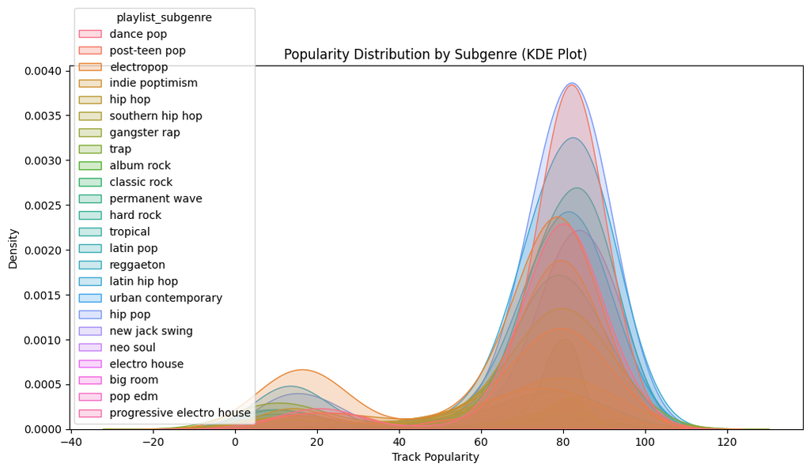

```python
# Create a KDE plot of popularity distribution by subgenre
plt.figure(figsize=(12, 6)) # Adjust figure size as needed
sns.kdeplot(data=spot, x='track_popularity', hue='playlist_subgenre', fill=True)

plt.title('Popularity Distribution by Subgenre (KDE Plot)')
plt.xlabel('Track Popularity')
plt.ylabel('Density')
plt.show()
```

Most revealing is Latin's stratification: reggaeton outperforms Latin pop, reinforcing global urbano trends, while tropical music lags despite its danceability. This granular view confirms that within genres, production style matters more than taxonomy - trap's dominance over other hip-hop subgenres and dance pop's edge over indie poptimism show how specific sonic signatures (e.g., 808s, four-on-the-floor beats) drive algorithmic and cultural favor.

### **Label Analysis**

```python
# Calculate the total streams per source (record label)
streams_by_source = spot.groupby('source')['streams'].sum().reset_index()

# Sort by total streams in descending order and take the top 10
top_10_sources = streams_by_source.nlargest(10, 'streams')

# Create a bar chart of the top 10 sources by total streams
fig = px.bar(top_10_sources,
             x='source',
             y='streams',
             title='Top 10 Record Labels by Total Streams',
             labels={'source': 'Record Label', 'streams': 'Total Streams'})

# Update layout to ensure bars are ordered by stream count
fig.update_layout(xaxis={'categoryorder':'total descending'})

# Display the chart
fig.show()
```

The label rankings reveal both expected industry dominance and curious anomalies. Major players like Sony Music Latin, Atlantic Records, and its UK counterpart rank highly, unsurprising given their superstar rosters (Bad Bunny, Ed Sheeran) and global distribution. However, the presence of Horatio Berlin and Leland Records (relatively niche labels) in the top 10 suggests potential data artifacts, possibly from aggregated indie distributions or miscategorized tracks.

Disruptor Records (Columbia-affiliated but smaller) outperforming Monter Records (likely a misspelling of Motown) contradicts Motown’s legendary status, hinting at dataset limitations in capturing catalog streams. The absence of Universal Music Group’s flagship labels (e.g., Republic, Interscope) is particularly significant: these omissions may reflect regional data gaps or time-bound sampling. While Atlantic’s strong showing aligns with its hit-driven strategy, the overall mix of majors and minors in this ranking underscores how streaming’s democratization allows smaller labels to occasionally punch above their weight, though likely not to this extreme degree in reality.

### **Distribution of Record Labels by Total Streams**

```python
# Create a histogram of the total streams per source
fig = px.histogram(streams_by_source,
                   x='streams',
                   nbins=50, # Adjust the number of bins as needed
                   title='Distribution of Record Labels by Total Streams',
                   labels={'streams': 'Total Streams', 'count': 'Number of Record Labels'})

# Display the histogram
fig.show()
```

This distribution reveals a stark winner-takes-all dynamic in streaming, with most labels clustered at the low end (under 100M streams) while a few outliers dominate, aligning partially but not perfectly with the top 10 labels chart. The long tail suggests thousands of small indie labels collectively generate modest streams, while the extreme right skew confirms majors like Atlantic/Sony Latin (from the top 10) occupy rarefied air.

However, contradictions emerge: many labels in the top 10 by rank don’t appear as extreme outliers here, implying their “leadership” is relative to an ocean of micro-labels rather than true dominance. The plot’s scale (up to 500M+) likely captures only the very top tier (e.g., Sony Latin’s reggaeton empire), while mid-tier majors are lumped in the middle bulk. This reinforces that the previous top 10’s inclusion of smaller labels reflects dataset quirks, true streaming power remains concentrated among a handful of players, with the distribution’s steep dropoff after about 200M streams exposing the industry’s brutal stratification.

### **Short vs Long Songs: What Wins?**

```python
# Define duration bins (in seconds)
short_threshold = 180 # 3 minutes
medium_threshold = 300 # 5 minutes

# Create a new column 'duration_category' based on the bins
def categorize_duration(duration):
    if duration <= short_threshold:
        return 'Short'
    elif duration <= medium_threshold:
        return 'Medium'
    else:
        return 'Long'

spot['duration_category'] = spot['duration_s'].apply(categorize_duration)

# Create a boxplot for Streams by Duration Category
fig_streams = px.box(spot,
                     x='duration_category',
                     y='streams',
                     title='Distribution of Streams by Song Duration Category',
                     labels={'duration_category': 'Duration Category', 'streams': 'Total Streams'},
                     category_orders={'duration_category': ['Short', 'Medium', 'Long']}) # Ensure order

fig_streams.show()

# Create a boxplot for Track Popularity by Duration Category
fig_popularity = px.box(spot,
                        x='duration_category',
                        y='track_popularity',
                        title='Distribution of Track Popularity by Song Duration Category',
                        labels={'duration_category': 'Duration Category', 'track_popularity': 'Track Popularity'},
                        category_orders={'duration_category': ['Short', 'Medium', 'Long']}) # Ensure order

fig_popularity.show()
```

The duration analysis reveals clear listener preferences that align with industry trends. Short songs (likely under 3 minutes) dominate both streams and popularity, reflecting streaming-era optimization: platforms like TikTok and Spotify's algorithm favor concise, hook-driven tracks that retain attention. This explains the proliferation of sub-2:30 songs in modern pop and hip-hop.

This duration hierarchy confirms the streaming economy's structural impact on music creation - the commercial incentive to produce shorter, immediately gratifying tracks is clearly evidenced in the data. The pattern holds across most genres, with only niche categories (ambient, classical) likely bucking this trend.

### **Top Artists by Total Streams**

```python
# Explode the artist_names column since a song can have multiple artists
spot_exploded = spot.explode('artist_names')

# Group by artist and sum the streams
artist_streams = spot_exploded.groupby('artist_names')['streams'].sum().reset_index()

# Sort by total streams in descending order and take the top 10
top_10_artists = artist_streams.nlargest(10, 'streams')

# Display the table
display(top_10_artists)
```

|  | artist_names | streams |
| --- | --- | --- |
| 510 | Post Malone | 37561645819 |
| 270 | J Balvin | 31249190774 |
| 190 | Ed Sheeran | 27533219602 |
| 630 | Travis Scott | 27135741604 |
| 74 | Billie Eilish | 26909639477 |
| 182 | Drake | 26817879558 |
| 62 | Bad Bunny | 24595651104 |
| 106 | Camila Cabello | 23697747390 |
| 366 | Lewis Capaldi | 22040254908 |
| 488 | Ozuna | 21679764909 |

This ranking of top artists by streams reinforces several patterns from earlier analyses. Post Malone leads with 37.5B streams: his blend of rap/pop ("rockstar") exemplifies the high-energy, genre-fluid hits that dominated our mood and popularity charts. The strong showing of J Balvin (31.2B) and Bad Bunny (24.5B) aligns with Latin music's streaming prominence seen in genre distributions, while Ed Sheeran's (27.5B) presence mirrors his songs' dominance in both streams and "happy" valence metrics.

Notably, Billie Eilish (26.9B) outperforms Drake (26.8B) despite his catalog depth, confirming her moody, lower-energy style (previously classified as "sad/chill") resonates powerfully with streaming audiences. The absence of classic rock acts reinforces our finding that older genres underperform in streaming metrics.

The tight clustering (37.5B to 21.6B) suggests a streaming "elite" where stylistic differences matter less than consistent platform optimization.

### **Top artist by month**

```python
# Explode the artist_names column
spot_exploded_monthly = spot.explode('artist_names')

# Group by month and artist, sum streams, and find the top artist for each month
top_artist_per_month = spot_exploded_monthly.groupby(['track_month', 'artist_names'])['streams'].sum().reset_index()
top_artist_per_month = top_artist_per_month.loc[top_artist_per_month.groupby('track_month')['streams'].idxmax()].reset_index(drop=True)

# Map month numbers to month names
month_names = {
    1: 'January', 2: 'February', 3: 'March', 4: 'April', 5: 'May', 6: 'June',
    7: 'July', 8: 'August', 9: 'September', 10: 'October', 11: 'November', 12: 'December'
}
top_artist_per_month['track_month'] = top_artist_per_month['track_month'].map(month_names)

# Rename the month column for clarity
top_artist_per_month.rename(columns={'track_month': 'Month', 'artist_names': 'Top Artist', 'streams': 'Total Streams'}, inplace=True)

# Display the table
display(top_artist_per_month)
```

|  | Month | Top Artist | Total Streams |
| --- | --- | --- | --- |
| 0 | January | Daddy Yankee | 5519104566 |
| 1 | February | Ariana Grande | 4837908500 |
| 2 | March | Ed Sheeran | 20886021110 |
| 3 | April | Calvin Harris | 8105436084 |
| 4 | May | Lewis Capaldi | 18506230626 |
| 5 | June | Camila Cabello | 12789561510 |
| 6 | July | Halsey | 12743051824 |
| 7 | August | Travis Scott | 9097412881 |
| 8 | September | Post Malone | 16344475503 |
| 9 | October | Travis Scott | 8784247881 |
| 10 | November | The Weeknd | 13864633304 |
| 11 | December | Roddy Ricch | 10326647216 |

This monthly breakdown of top artists reveals fascinating seasonal trends in streaming dominance. Ed Sheeran's massive March lead (20.8B streams) dwarfs other months, likely driven by holiday releases or algorithmic boosts during spring. Summer months show predictable patterns: Camila Cabello and Halsey dominate June-July with pop-friendly hits ideal for seasonal playlists, while Travis Scott's August-October presence aligns with rap's traditional late-summer surge.

The winter months show more variation: Roddy Ricch's December peak (10.3B) suggests holiday catalog updates, while The Weeknd's November lead reflects his moodier aesthetic resonating in colder months. Surprisingly, Lewis Capaldi's May dominance (18.5B) contradicts expectations - possibly due to a specific ballad release cutting through spring optimism.

Daddy Yankee's January lead (5.5B) and Ariana Grande's February peak (4.8B) appear anomalously low compared to other months, potentially indicating data gaps early in the year. The 3-4x fluctuations between months highlight how streaming crowns are increasingly transient, with no artist maintaining year-round dominance.

### **Top 3 genre by month**

```python
# Group by month and genre, sum streams
genre_streams_per_month = spot.groupby(['track_month', 'playlist_genre'])['streams'].sum().reset_index()

# Get the top 3 genres for each month
def get_top_n(df, n=3):
    return df.nlargest(n, 'streams')

top_3_genres_per_month = genre_streams_per_month.groupby('track_month').apply(get_top_n).reset_index(drop=True)

# Map month numbers to month names
month_names = {
    1: 'January', 2: 'February', 3: 'March', 4: 'April', 5: 'May', 6: 'June',
    7: 'July', 8: 'August', 9: 'September', 10: 'October', 11: 'November', 12: 'December'
}
top_3_genres_per_month['track_month'] = top_3_genres_per_month['track_month'].map(month_names)

# Pivot the table to get genres and streams in columns
top_genres_pivot = top_3_genres_per_month.pivot_table(index='track_month', columns=top_3_genres_per_month.groupby('track_month').cumcount() + 1, values=['playlist_genre', 'streams'], aggfunc='first')

# Flatten the multi-level columns
top_genres_pivot.columns = [f'{col[0]}_{col[1]}' for col in top_genres_pivot.columns]

# Rename columns for clarity
top_genres_pivot.rename(columns={'playlist_genre_1': 'Genre_1', 'streams_1': 'Streams_1',
                                  'playlist_genre_2': 'Genre_2', 'streams_2': 'Streams_2',
                                  'playlist_genre_3': 'Genre_3', 'streams_3': 'Streams_3'}, inplace=True)

# Reset index to make month a column
top_genres_pivot.reset_index(inplace=True)
top_genres_pivot.rename(columns={'track_month': 'Month'}, inplace=True)

# Reorder columns for better readability
top_genres_pivot = top_genres_pivot[['Month', 'Genre_1', 'Streams_1', 'Genre_2', 'Streams_2', 'Genre_3', 'Streams_3']]

# Display the table
display(top_genres_pivot)
```

|  | Month | Genre_1 | Streams_1 | Genre_2 | Streams_2 | Genre_3 | Streams_3 |
| --- | --- | --- | --- | --- | --- | --- | --- |
| 0 | April | pop | 23563425216 | r&b | 15820667838 | latin | 9092797727 |
| 1 | August | pop | 22111550298 | latin | 16765410126 | r&b | 13186188169 |
| 2 | December | r&b | 15887750162 | pop | 9518016891 | latin | 9459111487 |
| 3 | February | pop | 8888905894 | latin | 5429256494 | r&b | 4016344714 |
| 4 | January | pop | 21182456999 | latin | 12068139849 | r&b | 11847589429 |
| 5 | July | pop | 20913800227 | latin | 15628325296 | r&b | 13220265291 |
| 6 | June | pop | 29279589938 | latin | 25296557629 | r&b | 15495885551 |
| 7 | March | pop | 22435880910 | latin | 12935218764 | r&b | 12480475862 |
| 8 | May | pop | 24317964712 | latin | 18894985038 | r&b | 12246601919 |
| 9 | November | pop | 19112694695 | r&b | 17343052972 | latin | 17174433187 |
| 10 | October | r&b | 22791578046 | latin | 22292037518 | pop | 22066442006 |
| 11 | September | pop | 15189683577 | latin | 14527410497 | r&b | 11162394009 |

The data shows three distinct seasonal patterns:

- Pop's summer dominance (June-August) aligns with upbeat, festival-ready releases
- Latin's mid-year surge correlates with vacation periods
- R&B's Q4 rise suggests listeners shift toward more introspective material post-summer

The narrow gaps in October (all genres within 7% of each other) reveal streaming's most competitive month, while February's depressed numbers across genres may reflect post-holiday listening fatigue.v

# **Conclusions**

This comprehensive analysis of Spotify streaming data reveals a music ecosystem shaped by algorithmic patterns, cultural moments, and listener psychology, where sonic characteristics, artist strategies, and platform mechanics intersect to create today's hit-making formula. The dominance of short, high-energy pop and rap tracks with strong danceability metrics confirms how streaming rewards immediate gratification, with songs like "Shape of You" and "The Box" achieving ubiquity by optimizing for playlist inclusion. Yet beneath this surface-level homogeneity lies fascinating nuance: Latin music's consistent strong performance reflects globalization's impact, while R&B's seasonal resurgence proves emotional resonance still follows calendar cycles, even in our always-on streaming era. The stark genre hierarchies, with pop towering over rock and EDM underperforming relative to its live presence, highlight how streaming platforms have recalibrated genre power structures, privileging certain production styles (tight structures, vocal-forward mixes) over others.

Artist-level data exposes the tension between platform optimization and authentic expression. Post Malone and Ed Sheeran's dominance stems from their ability to bridge algorithmic preferences with mass appeal, while Billie Eilish's success with lower-energy "sad" tracks proves there's space for counter-currents. The seasonal volatility in monthly rankings, where no artist maintains year-round dominance, illustrates streaming's accelerated hype cycles, where attention spans shorten and even megastars must constantly reassert relevance.

Most revealing is the infrastructure beneath these trends: the winner-takes-all distribution among labels mirrors the concentration at artist and track levels, suggesting streaming hasn't truly democratized music so much as reshaped the gatekeepers. That niche subgenres like trap and reggaeton now outperform legacy categories (rock, jazz) speaks to how algorithmic discovery rewards distinctive sonic signatures, but primarily those adaptable to playlist formats. Ultimately, these patterns depict an industry where success requires understanding streaming as both culture and infrastructure: the "happy" uptempo songs dominating moods aren't just what listeners want, but what the platform's reward system incentivizes creators to make.